# Reproducible Data - Week 2 Assignment

Lisa Mudgett

July 7, 2017

## Assignment

It is now possible to collect a large amount of data about personal movement using activity monitoring devices such as a Fitbit, Nike Fuelband, or Jawbone Up. These type of devices are part of the “quantified self” movement - a group of enthusiasts who take measurements about themselves regularly to improve their health, to find patterns in their behavior, or because they are tech geeks. But these data remain under-utilized both because the raw data are hard to obtain and there is a lack of statistical methods and software for processing and interpreting the data.

This assignment makes use of data from a personal activity monitoring device. This device collects data at 5 minute intervals through out the day. The data consists of two months of data from an anonymous individual collected during the months of October and November, 2012 and include the number of steps taken in 5 minute intervals each day.

The data for this assignment can be downloaded from the course web site:

```
Dataset: Activity monitoring data [52K]
```

The variables included in this dataset are:

```
steps: Number of steps taking in a 5-minute interval (missing values are coded as NA)
date: The date on which the measurement was taken in YYYY-MM-DD format
interval: Identifier for the 5-minute interval in which measurement was taken
```

The dataset is stored in a comma-separated-value (CSV) file and there are a total of 17,568 observations in this dataset.

## The Data!

Let’s read in the data and call the data set “activity.”

```r
activity <- read.csv("activity.csv")
```

Let’s check out what the data look like.

```r
str(activity)
```

```
## 'data.frame':    17568 obs. of  3 variables:
##  $ steps   : int  NA NA NA NA NA NA NA NA NA NA ...
##  $ date    : Factor w/ 61 levels "2012-10-01","2012-10-02",..: 1 1 1 1 1 1 1 1 1 1 ...
##  $ interval: int  0 5 10 15 20 25 30 35 40 45 ...
```

```r
head(activity)
```

```
##   steps       date interval
## 1    NA 2012-10-01        0
## 2    NA 2012-10-01        5
## 3    NA 2012-10-01       10
## 4    NA 2012-10-01       15
## 5    NA 2012-10-01       20
## 6    NA 2012-10-01       25
```

Okay, now that we have an overview of what our data are like, let’s get to work!

## Steps Taken Each Day

The first couple of assignment items are: - Histogram of the total number of steps taken each day - Mean and median number of steps taken each day

Let’s plot the histogram. We’ll sum the steps by day first, using tapply.

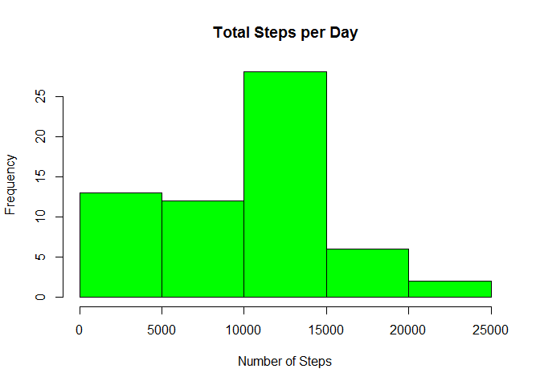

```r
totalsteps <- tapply(activity$steps, activity$date, FUN=sum, na.rm=TRUE)

hist(totalsteps, main=paste("Total Steps per Day"), col = "green", xlab="Number of Steps")
```

There we go! From this data, the most frequent daily step total falls between 10,000 and 15,000 steps. Nice!

The next requirement is to find the mean and median of the total daily steps.

```r
stepsmean <- mean(totalsteps)
stepsmean
```

```
## [1] 9354.23
```

```r
stepsmedian <- median(totalsteps)
stepsmedian
```

```
## [1] 10395
```

## Daily Activity Pattern

The next items in the assignment are: - Time series plot of the average number of steps taken - The 5-minute interval that, on average, contains the maximum number of steps

So let’s resummarize our data by 5-minute intervals, and then look at a sample of the summarized data.

```r
stepsbyint <- tapply(activity$steps, activity$interval, FUN=mean, na.rm=TRUE)

head(stepsbyint)
```

```
##         0         5        10        15        20        25
## 1.7169811 0.3396226 0.1320755 0.1509434 0.0754717 2.0943396
```

And let’s plot!

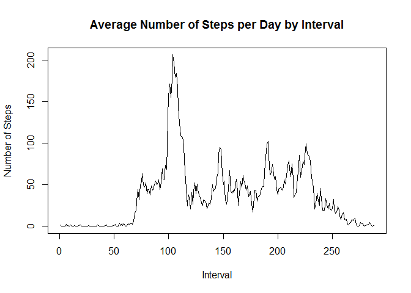

```r
plot(stepsbyint, type="l", xlab="Interval", ylab="Number of Steps",main="Average Number of Steps per Day by Interval")
```

Let’s find the interval with the maximum average daily steps.

```r
maxint <- stepsbyint[which.max(stepsbyint)]
maxint
```

```
##      835
## 206.1698
```

So the interval with the maximum average steps is 835, with average steps in that interval of 206. Cool!

Moving right along…

## Imputing Missing Values

Note that there are a number of days/intervals where there are missing values (coded as NA). The presence of missing days may introduce bias into some calculations or summaries of the data.

- Calculate and report the total number of missing values in the dataset (i.e. the total number of rows with NAs)

```r
sum(is.na(activity))
```

```
## [1] 2304
```

- Devise a strategy for filling in all of the missing values in the dataset. The strategy does not need to be sophisticated. For example, you could use the mean/median for that day, or the mean for that 5-minute interval, etc.

```r
# Copy the original data to play with
impute <- activity

# Replace the missing values with the average steps for that interval
impute$steps[which(is.na(activity$steps))]  <-  as.vector(mean(as.character(activity[which(is.na(activity$steps)),3])))
```

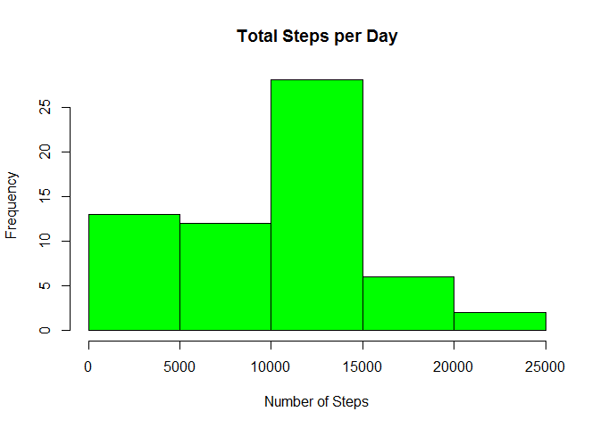

```r
stepseachday <- tapply(impute$steps, impute$date, sum, na.rm=TRUE)
hist(stepseachday, main=paste("Total Steps per Day"), col = "green", xlab="Number of Steps")
```

```r
# Calculate the new mean and median

meanimpute <- mean(stepseachday)
meanimpute
```

```
## [1] 9354.23
```

```r
medianimpute <- median(stepseachday)
medianimpute
```

```
## [1] 10395
```

## Are there differences in activity patterns between weekdays and weekends?

For this part the weekdays() function may be of some help here. Use the dataset with the filled-in missing values for this part.

- Create a new factor variable in the dataset with two levels - “weekday” and “weekend” indicating whether a given date is a weekday or weekend day.

```r
daytype <- function(date) {
    day <- weekdays(date)
    if (day %in% c("Monday", "Tuesday", "Wednesday", "Thursday", "Friday"))
        return("weekday")
    else if (day %in% c("Saturday", "Sunday"))
        return("weekend")
    else
        stop("invalid date")
}
impute$date <- as.Date(impute$date)
impute$day <- sapply(impute$date, FUN=daytype)

# Let's see what that looks like:

head(impute)
```

```
##   steps       date interval     day
## 1    NA 2012-10-01        0 weekday
## 2    NA 2012-10-01        5 weekday
## 3    NA 2012-10-01       10 weekday
## 4    NA 2012-10-01       15 weekday
## 5    NA 2012-10-01       20 weekday
## 6    NA 2012-10-01       25 weekday
```

- Make a panel plot containing a time series plot (i.e. type = “l”) of the 5-minute interval (x-axis) and the average number of steps taken, averaged across all weekday days or weekend days (y-axis). See the README file in the GitHub repository to see an example of what this plot should look like using simulated data.

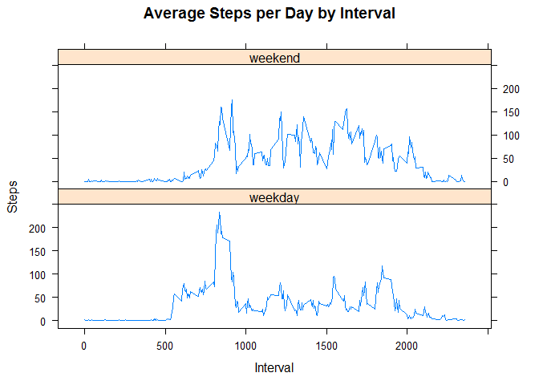

```r
stepsbyintimp <- aggregate(steps ~ interval + day, impute, mean)

library(lattice)

xyplot(stepsbyintimp$steps ~ stepsbyintimp$interval|stepsbyintimp$day, main="Average Steps per Day by Interval",xlab="Interval", ylab="Steps",layout=c(1,2), type="l")
```